# Practical Machine Learning Project

Hoang Viet Tran

## Background

Using devices such as *Jawbone Up*, *Nike FuelBand*, and *Fitbit* it is now possible to collect a large amount of data about personal activity relatively inexpensively. These type of devices are part of the quantified self movement – a group of enthusiasts who take measurements about themselves regularly to improve their health, to find patterns in their behavior, or because they are tech geeks. One thing that people regularly do is quantify how much of a particular activity they do, but they rarely quantify how well they do it. In this project, your goal will be to use data from accelerometers on the belt, forearm, arm, and dumbell of 6 participants. They were asked to perform barbell lifts correctly and incorrectly in 5 different ways. More information is available from the website here:[linked phrase] (http://groupware.les.inf.puc-rio.br/har) (see the section on the Weight Lifting Exercise Dataset).

## Data Analysis

### Getting the Data

**Read two datasets directly from urls**

```r
library(caret)
library(rattle)
```

```r
library(tidyr)
url_train<-"http://d396qusza40orc.cloudfront.net/predmachlearn/pml-training.csv"
url_test<-"http://d396qusza40orc.cloudfront.net/predmachlearn/pml-testing.csv"
#Read csv
training<-read.csv(url(url_train), na.strings = c("NA","#DIV/0!",""))
testing<-read.csv(url(url_test), na.strings = c("NA","#DIV/0!",""))
```

**Split the training dataset into two parts**

```r
#Partitioning the training set into two parts
set.seed(1234)
inTrain<-createDataPartition(y=training$classe,p=0.6, list=FALSE)
myTraining<-training[inTrain,]
myTesting<-training[-inTrain,]
```

**Cleaning the data**

```r
#Remove near zero variables
nzv_train<-nearZeroVar(myTraining, saveMetrics = TRUE)
myTraining<-myTraining[,nzv_train$nzv==FALSE]
nzv_test<-nearZeroVar(myTesting, saveMetrics = TRUE)
myTesting<-myTesting[,nzv_test$nzv==FALSE]

#Remove the first column
myTraining<-myTraining[c(-1)]

#Remove column with more than 60%
myTrainingTemp<-myTraining
for (i in 1:length(myTraining)) {
  if (sum(is.na(myTraining[,i]))/nrow(myTraining) >= .6) {
    for (j in 1:length(myTrainingTemp)) {
      if (length(grep(names(myTraining[i]),names(myTrainingTemp)[j]))==1) {
        myTrainingTemp<-myTrainingTemp[,-j]
      }
    }
  }
}
myTraining<-myTrainingTemp
rm(myTrainingTemp)

#Apply same filter to myTesting and testing dataset
clean1<-colnames(myTraining)
clean2<-colnames(myTraining[,-58])
myTesting<-myTesting[clean1]
testing<-testing[clean2]

#Coerce class type in testing to be the same as myTraining
for (i in 1:length(testing)) {
  for (j in 1:length(myTraining)) {
    if (length(grep(names(myTraining[i]),names(testing)[j]))==1) {
      class(testing[i])<-class(myTraining[j])
    }
  }
}

# To get the same class between testing and myTraining
testing <- rbind(myTraining[2, -58] , testing)
testing <- testing[-1,]
dim(myTraining); dim(myTesting); dim(testing)
```

```
## [1] 11776    58
```

```
## [1] 7846   58
```

```
## [1] 20 57
```

### Exploratory Data Analysis

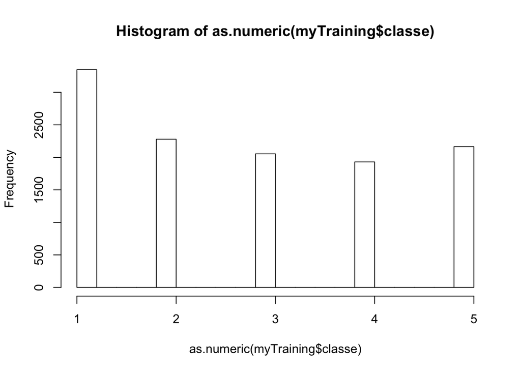

```r
hist(as.numeric(myTraining$classe))
```

### Prediction using Decision Trees

**Fitting model**

```r
modFit1<-train(classe~.,data=myTraining,method="rpart")
```

[figure not shown]

```r
fancyRpartPlot(modFit1$finalModel)
```

**Predicting and Validating on myTesting dataset**

```r
pred1<-predict(modFit1,myTesting)
cM1<-confusionMatrix(pred1,myTesting$classe)
cM1
```

```
## Confusion Matrix and Statistics
##
##           Reference
## Prediction    A    B    C    D    E
##          A 1465  167    1    0    0
##          B  302  562  165  380   87
##          C  461  789 1202  906  716
##          D    0    0    0    0    0
##          E    4    0    0    0  639
##
## Overall Statistics
##
##                Accuracy : 0.493
##                  95% CI : (0.4819, 0.5041)
##     No Information Rate : 0.2845
##     P-Value [Acc > NIR] : < 2.2e-16
##
##                   Kappa : 0.3649
##  Mcnemar's Test P-Value : NA
##
## Statistics by Class:
##
##                      Class: A Class: B Class: C Class: D Class: E
## Sensitivity            0.6564  0.37022   0.8787   0.0000  0.44313
## Specificity            0.9701  0.85240   0.5567   1.0000  0.99938
## Pos Pred Value         0.8971  0.37567   0.2950      NaN  0.99378
## Neg Pred Value         0.8765  0.84945   0.9560   0.8361  0.88852
## Prevalence             0.2845  0.19347   0.1744   0.1639  0.18379
## Detection Rate         0.1867  0.07163   0.1532   0.0000  0.08144
## Detection Prevalence   0.2081  0.19067   0.5192   0.0000  0.08195
## Balanced Accuracy      0.8132  0.61131   0.7177   0.5000  0.72125
```

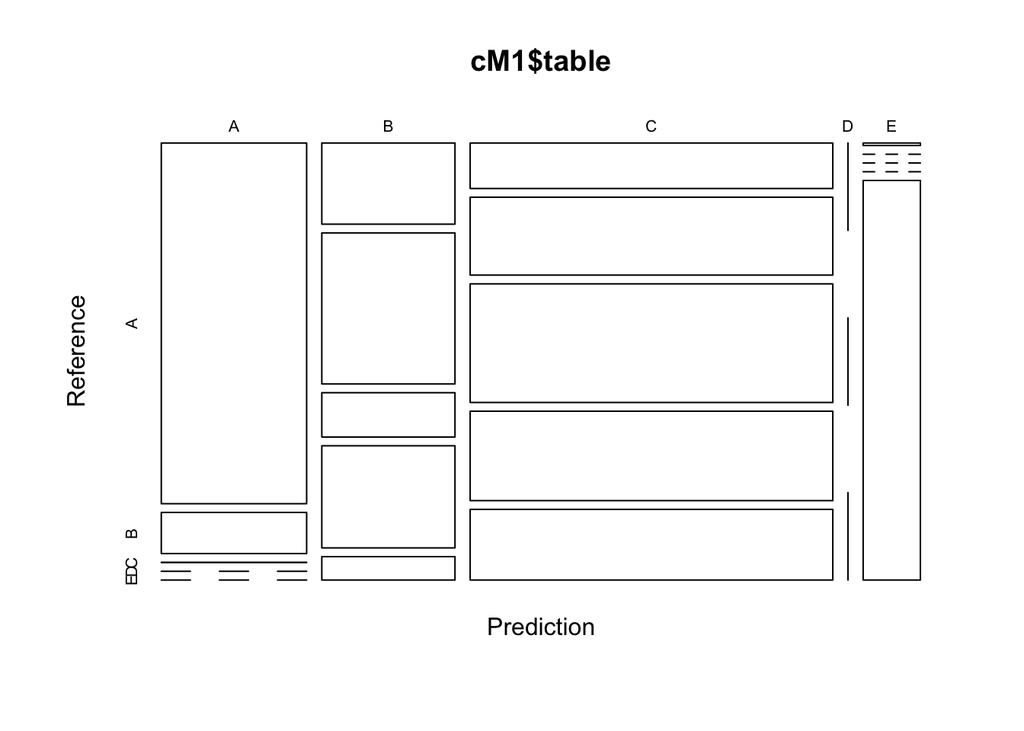

```r
plot(cM1$table,col=cM1$byClass)
```

### Prediction using Random Forests

**Fitting model**

```r
modFit2<-train(classe~.,data=myTraining,method="rf",trControl=trainControl(method = "cv"))
```

**Predicting and Validating on myTesting dataset**

```r
pred2<-predict(modFit2,myTesting)
cM2<-confusionMatrix(pred2,myTesting$classe)
cM2
```

```
## Confusion Matrix and Statistics
##
##           Reference
## Prediction    A    B    C    D    E
##          A 2232    2    0    0    0
##          B    0 1516    1    0    0
##          C    0    0 1367    3    0
##          D    0    0    0 1283    0
##          E    0    0    0    0 1442
##
## Overall Statistics
##
##                Accuracy : 0.9992
##                  95% CI : (0.9983, 0.9997)
##     No Information Rate : 0.2845
##     P-Value [Acc > NIR] : < 2.2e-16
##
##                   Kappa : 0.999
##  Mcnemar's Test P-Value : NA
##
## Statistics by Class:
##
##                      Class: A Class: B Class: C Class: D Class: E
## Sensitivity            1.0000   0.9987   0.9993   0.9977   1.0000
## Specificity            0.9996   0.9998   0.9995   1.0000   1.0000
## Pos Pred Value         0.9991   0.9993   0.9978   1.0000   1.0000
## Neg Pred Value         1.0000   0.9997   0.9998   0.9995   1.0000
## Prevalence             0.2845   0.1935   0.1744   0.1639   0.1838
## Detection Rate         0.2845   0.1932   0.1742   0.1635   0.1838
## Detection Prevalence   0.2847   0.1933   0.1746   0.1635   0.1838
## Balanced Accuracy      0.9998   0.9993   0.9994   0.9988   1.0000
```

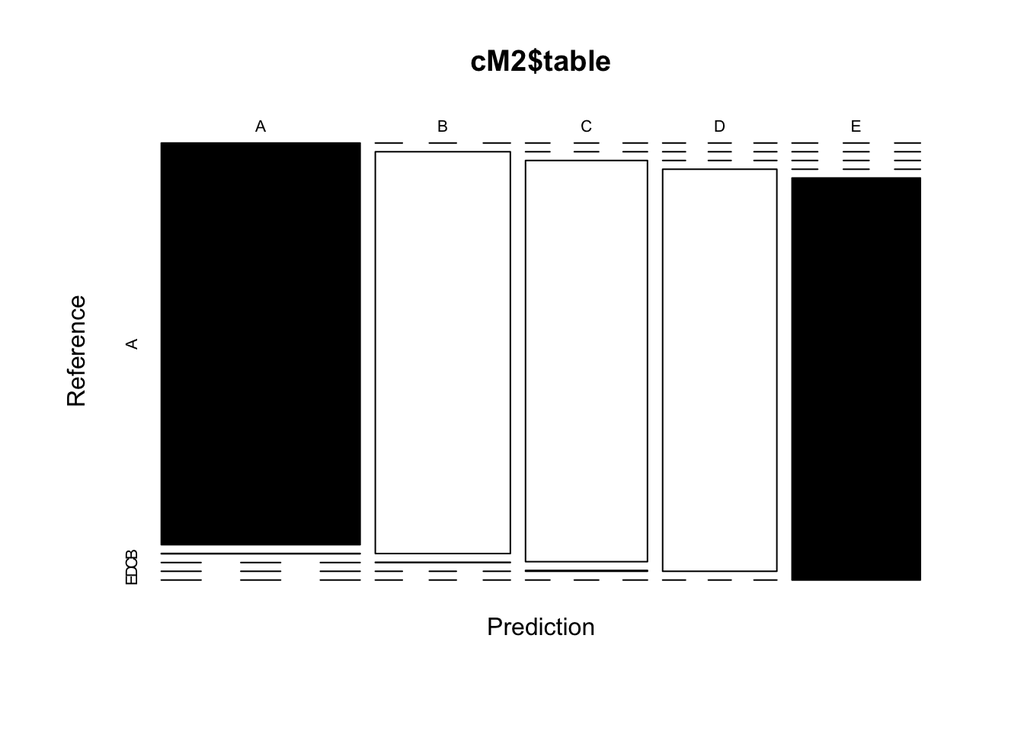

```r
plot(cM2$table,col=cM2$byClass)
```

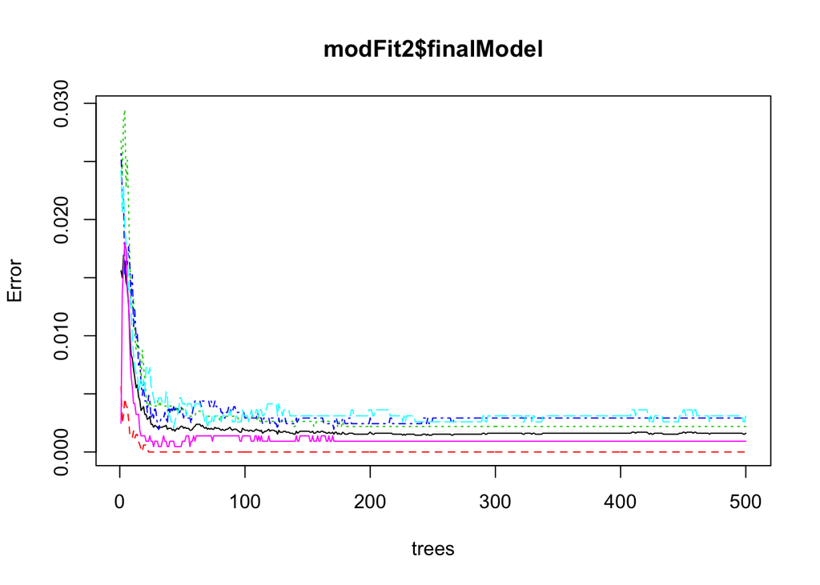

```r
plot(modFit2$finalModel)
```

### Prediction using Generalize Boosted Regression

**Fitting model**

```r
modFit3<-train(classe~.,data=myTraining,method="gbm",trControl=trainControl(method = "cv"),verbose = FALSE)
```

**Predicting and Validating on myTesting dataset**

```r
pred3<-predict(modFit3,myTesting)
cM3<-confusionMatrix(pred3,myTesting$classe)
cM3
```

```
## Confusion Matrix and Statistics
##
##           Reference
## Prediction    A    B    C    D    E
##          A 2232    4    0    0    0
##          B    0 1509    1    0    0
##          C    0    3 1356    6    0
##          D    0    2   11 1279    3
##          E    0    0    0    1 1439
##
## Overall Statistics
##
##                Accuracy : 0.996
##                  95% CI : (0.9944, 0.9973)
##     No Information Rate : 0.2845
##     P-Value [Acc > NIR] : < 2.2e-16
##
##                   Kappa : 0.995
##  Mcnemar's Test P-Value : NA
##
## Statistics by Class:
##
##                      Class: A Class: B Class: C Class: D Class: E
## Sensitivity            1.0000   0.9941   0.9912   0.9946   0.9979
## Specificity            0.9993   0.9998   0.9986   0.9976   0.9998
## Pos Pred Value         0.9982   0.9993   0.9934   0.9876   0.9993
## Neg Pred Value         1.0000   0.9986   0.9981   0.9989   0.9995
## Prevalence             0.2845   0.1935   0.1744   0.1639   0.1838
## Detection Rate         0.2845   0.1923   0.1728   0.1630   0.1834
## Detection Prevalence   0.2850   0.1925   0.1740   0.1651   0.1835
## Balanced Accuracy      0.9996   0.9970   0.9949   0.9961   0.9989
```

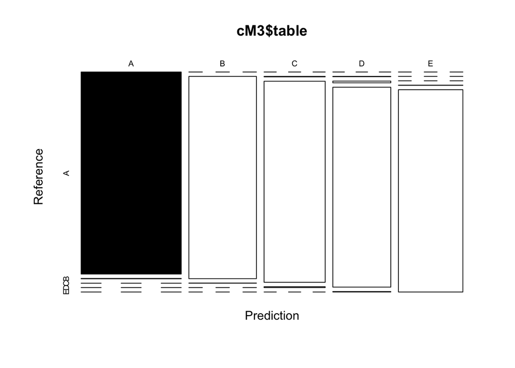

```r
plot(cM3$table,col=cM3$byClass)
```

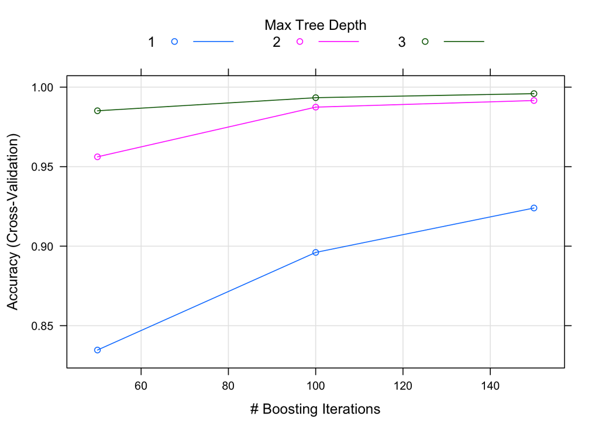

```r
plot(modFit3)
```

### Predicting result on test data

```r
pred4<-predict(modFit2,testing)
pred4
```

```
##  [1] B A B A A E D B A A B C B A E E A B B B
## Levels: A B C D E
```